## CSE-221710304030-K Eswar Sai Suhas Reddy

### Dataset link:https://www.kaggle.com/alxmamaev/flowers-recognition

# Context

# Content

The pictures are divided into five classes: daisy, tulip, rose, sunflower, dandelion. For each class there are about 800 photos. Photos are not high resolution, about 320x240 pixels. Photos are not reduced to a single size, they have different proportions!

# Acknowledgements

The data collection is based on scraped data from flickr, google images, and yandex images.

# Problem Statement

What kind of flower is that?

```python
from google.colab import drive
drive.mount("/content/drive")
```

[output not shown]

### Importing the libraries

```python
# importing required libraries
import os
import tensorflow as tf
import tensorflow.keras as keras
import numpy as np
import matplotlib.pyplot as plt
%matplotlib inline
import pandas as pd
```

```python
os.listdir("/content/drive/My Drive/flowers")
```

```
['tulip',
 'sunflower',
 'dandelion',
 'rose',
 'daisy',
 'DandelionLead.jpg',
 'daisy.jpg',
 'sunflower.jpg',
 'rose.jpg',
 'tulip.jpg']
```

```python
# categories in the data set
base_path = '/content/drive/My Drive/flowers'
categories = ['daisy', 'dandelion', 'roses', 'sunflowers', 'tulips']
```

```python
mapping = {}
count = 0
for i in categories:
    mapping[count] = i
    count+=1
```

```python
print(len(os.listdir("/content/drive/My Drive/flowers/sunflower")))
```

```
734
```

```python
print(len(os.listdir("/content/drive/My Drive/flowers/tulip")))
```

```
984
```

```python
print(len(os.listdir("/content/drive/My Drive/flowers/dandelion")))
```

```
1055
```

```python
print(len(os.listdir("/content/drive/My Drive/flowers/rose")))
```

```
784
```

```python
print(len(os.listdir("/content/drive/My Drive/flowers/daisy")))
```

```
769
```

## Data visualization

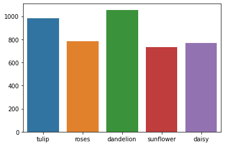

```python
import seaborn as sns
sns.barplot(x=['tulip','roses','dandelion','sunflower','daisy'] , y=[len(os.listdir(base_path+'/tulip')),
                                                                    len(os.listdir(base_path+'/rose')),
                                                                    len(os.listdir(base_path+'/dandelion')),
                                                                    len(os.listdir(base_path+'/sunflower')),
                                                                    len(os.listdir(base_path+'/daisy'))])
```

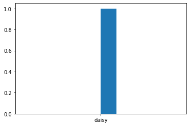

```python
plt.hist(categories[0])
```

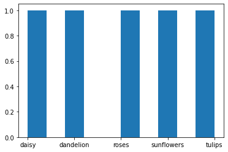

```python
plt.hist(categories)
```

### Image preprocessing

```python
from keras.preprocessing.image import ImageDataGenerator
img_height = 150
img_width = 150
C = 5
batch_size = 64
nb_epochs = 30
train_data_dir = '/content/drive/My Drive/flowers'

# all the images will be rescaled by 1./255

train_datagen = ImageDataGenerator(rescale=1./255,
                                    horizontal_flip=True,  # randomly flip images
                                    vertical_flip=False,  # randomly flip images
                                    zoom_range = 0.2,
                                    validation_split=0.3) # set validation split

# flow traing images in batches of 64 using  train_data generator
train_generator = train_datagen.flow_from_directory(
    train_data_dir,  # This is the source directory for training images
    target_size=(img_height, img_width),  # All images will be resized to 150x150
    batch_size=batch_size,
    shuffle = True,

# Since we use Categoricalrossentropy loss, we need categorical labels

    class_mode='categorical',
    subset='training') # set as training data

# Flow validation images in batches of 64 using val_datagen generator

validation_generator = train_datagen.flow_from_directory(
    train_data_dir, # same directory as training data
    target_size=(img_height, img_width),
    batch_size=batch_size,
    class_mode='categorical',
    subset='validation')
```

```
Found 3028 images belonging to 5 classes.
Found 1295 images belonging to 5 classes.
```

```
(64, 150, 150, 3)
(64, 5)
```

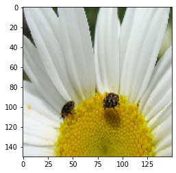

```python
imgs,labels=train_generator.next()
print(imgs.shape)
print(labels.shape)
plt.imshow(imgs[0,:,:,:]) # do display image
```

[figure not shown]

```python
plt.figure(figsize=(16,16))
pos=1 ## plot position
for i in range(20):
  plt.subplot(4,5,pos)
  plt.imshow(imgs[i,:,:,:])# to display image
  plt.title(labels[i])
  plt.axis('off')
  pos +=1
```

# Bulding the model 1

```python
from tensorflow.keras.models import Sequential
from tensorflow.keras.layers import Conv2D,Dense,Flatten,MaxPooling2D, Dropout
```

```python
model = Sequential()
## add a conv layer followed by maxpooling

# First convolution extracts 32 filters that are 5x5
# Convolution is followed by max-pooling layer with a 2x2 window

model.add(Conv2D(filters = 32, kernel_size = (5,5),padding = 'Same',activation ='relu', input_shape = (150,150,3)))
model.add(MaxPooling2D(pool_size=(2,2)))

# params = ((n*m*k)+1)*f = ((5*5*3)+1)*32=2432

# Second convolution extracts 64 filters that are 3x3
# Convolution is followed by max-pooling layer with a 2x2 window

model.add(Conv2D(filters = 64, kernel_size = (3,3),padding = 'Same',activation ='relu'))
model.add(MaxPooling2D(pool_size=(2,2), strides=(2,2)))

# params = ((n*m*k)+1)*f = ((3*3*32)+1)*64=18496

# Third convolution extracts 96 filters that are 3x3
# Convolution is followed by max-pooling layer with a 2x2 window

model.add(Conv2D(filters =96, kernel_size = (3,3),padding = 'Same',activation ='relu'))
model.add(MaxPooling2D(pool_size=(2,2), strides=(2,2)))

# params = ((n*m*k)+1)*f = ((3*3*64)+1)*96=55392

# fourth convolution extracts 96 filters that are 3x3
# Convolution is followed by max-pooling layer with a 2x2 window

model.add(Conv2D(filters = 96, kernel_size = (3,3),padding = 'Same',activation ='relu'))
model.add(MaxPooling2D(pool_size=(2,2), strides=(2,2)))

# params = ((n*m*k)+1)*f = ((3*3*96)+1)*96= 83040

# Flatten feature map to a 1-dim tensor so we can add fully connected layers

model.add(Flatten())

# Create a fully connected layer with ReLU activation and 512 hidden units

model.add(Dense(512,activation='relu'))

# params = ((n*m*k)+1)*f = ((3*3*96)+1)*512= 3981824

# Create output layer with a multiple node and softmax activation

model.add(Dense(5, activation = "softmax"))

# let us see the summmary of the model

model.summary()
```

```
Model: "sequential_1"
_________________________________________________________________
Layer (type)                 Output Shape              Param #
=================================================================
conv2d_4 (Conv2D)            (None, 150, 150, 32)      2432
_________________________________________________________________
max_pooling2d_4 (MaxPooling2 (None, 75, 75, 32)        0
_________________________________________________________________
conv2d_5 (Conv2D)            (None, 75, 75, 64)        18496
_________________________________________________________________
max_pooling2d_5 (MaxPooling2 (None, 37, 37, 64)        0
_________________________________________________________________
conv2d_6 (Conv2D)            (None, 37, 37, 96)        55392
_________________________________________________________________
max_pooling2d_6 (MaxPooling2 (None, 18, 18, 96)        0
_________________________________________________________________
conv2d_7 (Conv2D)            (None, 18, 18, 96)        83040
_________________________________________________________________
max_pooling2d_7 (MaxPooling2 (None, 9, 9, 96)          0
_________________________________________________________________
flatten_1 (Flatten)          (None, 7776)              0
_________________________________________________________________
dense_2 (Dense)              (None, 512)               3981824
_________________________________________________________________
dense_3 (Dense)              (None, 5)                 2565
=================================================================
Total params: 4,143,749
Trainable params: 4,143,749
Non-trainable params: 0
_________________________________________________________________
```

# Compiling the model

```python
import tensorflow as tf
model.compile(loss=tf.keras.losses.CategoricalCrossentropy(),metrics=['accuracy'])
```

```python
history = model.fit(train_generator,epochs=30,validation_data=validation_generator,batch_size=20)
```

[output not shown]

# Visulization of accuracy and loss of traing and validation images

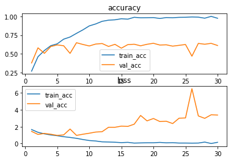

```python
train_acc = history.history['accuracy']
val_acc = history.history['val_accuracy']
train_loss = history.history['loss']
val_loss = history.history['val_loss']


epochs=list(range(1,31))
plt.subplot(2,1,1)
plt.plot(epochs,train_acc,label='train_acc')
plt.plot(epochs,val_acc,label='val_acc')
plt.title('accuracy')
plt.legend()


plt.subplot(2,1,2)
plt.plot(epochs,train_loss,label='train_acc')
plt.plot(epochs,val_loss,label='val_acc')
plt.title('loss')
plt.legend()
```

training loss: 0.1430 training accuracy: 0.9742 valdation loss: 3,3882 validation accuracy: 0.6116

# Prediction against user sample

### Prediction of Rose

```
<class 'PIL.JpegImagePlugin.JpegImageFile'>
(238, 212, 3)
<class 'numpy.ndarray'>
(150, 150, 3)
(1, 150, 150, 3)
```

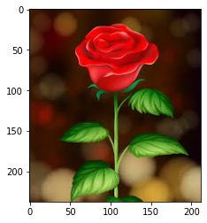

```python
from tensorflow.keras.preprocessing import image
import numpy as np
img = image.load_img('/content/drive/My Drive/flowers/rose.jpg')
print(type(img))
plt.imshow(img)
#print(img.shape)

img = tf.keras.preprocessing.image.img_to_array(img)
print(img.shape)
print(type(img))
img = tf.image.resize(img,(150,150))

#scaling
img = img/255
print(img.shape)
img = np.expand_dims(img,axis=0)
print(img.shape)
```

```python
model.predict(img).round(3)
```

```
array([[0.038, 0.   , 0.898, 0.   , 0.064]], dtype=float32)
```

```python
print(f"The Photo is in the category of {mapping[model.predict_classes(img)[0]]}")
```

```
The Photo is in the category of roses
```

### prediction of Dandelion

```
<class 'PIL.JpegImagePlugin.JpegImageFile'>
(681, 914, 3)
<class 'numpy.ndarray'>
(150, 150, 3)
(1, 150, 150, 3)
```

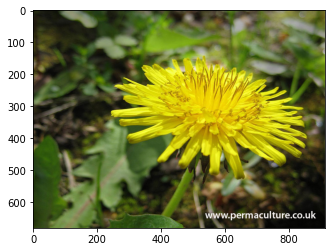

```python
img = image.load_img('/content/drive/My Drive/flowers/DandelionLead.jpg')
print(type(img))
plt.imshow(img)
#print(img.shape)

img = tf.keras.preprocessing.image.img_to_array(img)
print(img.shape)
print(type(img))
img = tf.image.resize(img,(150,150))

#scaling
img = img/255
print(img.shape)
img = np.expand_dims(img,axis=0)
print(img.shape)
```

```python
model.predict(img).round(3)
```

```
array([[0.   , 0.859, 0.001, 0.005, 0.135]], dtype=float32)
```

```python
print(f"The Photo is in the category of {mapping[model.predict_classes(img)[0]]}")
```

```
The Photo is in the category of dandelion
```

### Prediction of Daisy

```
<class 'PIL.JpegImagePlugin.JpegImageFile'>
(2000, 2200, 3)
<class 'numpy.ndarray'>
(150, 150, 3)
(1, 150, 150, 3)
```

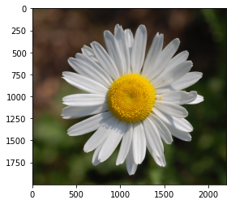

```python
img = image.load_img('/content/drive/My Drive/flowers/daisy.jpg')
print(type(img))
plt.imshow(img)
#print(img.shape)

img = tf.keras.preprocessing.image.img_to_array(img)
print(img.shape)
print(type(img))
img = tf.image.resize(img,(150,150))

#scaling
img = img/255
print(img.shape)
img = np.expand_dims(img,axis=0)
print(img.shape)
```

```python
model.predict(img).round(3)
```

```
array([[1., 0., 0., 0., 0.]], dtype=float32)
```

```python
print(f"The Photo is in the category of {mapping[model.predict_classes(img)[0]]}")
```

```
The Photo is in the category of daisy
```

### Prediction of Tulip

```
<class 'PIL.JpegImagePlugin.JpegImageFile'>
(450, 450, 3)
<class 'numpy.ndarray'>
(150, 150, 3)
(1, 150, 150, 3)
```

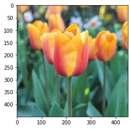

```python
img = image.load_img('/content/drive/My Drive/flowers/tulip.jpg')
print(type(img))
plt.imshow(img)
#print(img.shape)

img = tf.keras.preprocessing.image.img_to_array(img)
print(img.shape)
print(type(img))
img = tf.image.resize(img,(150,150))

#scaling
img = img/255
print(img.shape)
img = np.expand_dims(img,axis=0)
print(img.shape)
```

```python
model.predict(img).round(3)
```

```
array([[0., 0., 0., 0., 1.]], dtype=float32)
```

```python
print(f"The Photo is in the category of {mapping[model.predict_classes(img)[0]]}")
```

```
The Photo is in the category of tulips
```

### prediction of sunflower

```
<class 'PIL.JpegImagePlugin.JpegImageFile'>
(646, 862, 3)
<class 'numpy.ndarray'>
(150, 150, 3)
(1, 150, 150, 3)
```

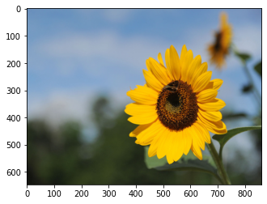

```python
img = image.load_img('/content/drive/My Drive/flowers/sunflower.jpg')
print(type(img))
plt.imshow(img)
#print(img.shape)

img = tf.keras.preprocessing.image.img_to_array(img)
print(img.shape)
print(type(img))
img = tf.image.resize(img,(150,150))

#scaling
img = img/255
print(img.shape)
img = np.expand_dims(img,axis=0)
print(img.shape)
```

```python
model.predict(img).round(3)
```

```
array([[0.   , 0.005, 0.   , 0.995, 0.   ]], dtype=float32)
```

```python
print(f"The Photo is in the category of {mapping[model.predict_classes(img)[0]]}")
```

```
The Photo is in the category of sunflowers
```

# Building the model 2

```python
from tensorflow.keras.models import Sequential
from tensorflow.keras.layers import Conv2D,Dense,Flatten,MaxPooling2D, Dropout
```

```python
model = Sequential()
## add a conv layer followed by maxpooling

# First convolution extracts 32 filters that are 5x5
# Convolution is followed by max-pooling layer with a 2x2 window

model.add(Conv2D(filters = 32, kernel_size = (5,5),padding = 'Same',activation ='relu', input_shape = (150,150,3)))
model.add(MaxPooling2D(pool_size=(2,2)))

model.add(Dropout(0.2))

# Second convolution extracts 64 filters that are 3x3
# Convolution is followed by max-pooling layer with a 2x2 window

model.add(Conv2D(filters = 64, kernel_size = (3,3),padding = 'Same',activation ='relu'))
model.add(MaxPooling2D(pool_size=(2,2), strides=(2,2)))

model.add(Dropout(0.3))

# Third convolution extracts 96 filters that are 3x3
# Convolution is followed by max-pooling layer with a 2x2 window

model.add(Conv2D(filters =96, kernel_size = (3,3),padding = 'Same',activation ='relu'))
model.add(MaxPooling2D(pool_size=(2,2), strides=(2,2)))

model.add(Dropout(0.3))

# fourth convolution extracts 96 filters that are 3x3
# Convolution is followed by max-pooling layer with a 2x2 window

model.add(Conv2D(filters = 96, kernel_size = (3,3),padding = 'Same',activation ='relu'))
model.add(MaxPooling2D(pool_size=(2,2), strides=(2,2)))

model.add(Dropout(0.2))

# fourth convolution extracts 96 filters that are 3x3
# Convolution is followed by max-pooling layer with a 2x2 window

model.add(Conv2D(filters = 96, kernel_size = (3,3),padding = 'Same',activation ='relu'))
model.add(MaxPooling2D(pool_size=(2,2), strides=(2,2)))

model.add(Dropout(0.2))

# Flatten feature map to a 1-dim tensor so we can add fully connected layers

model.add(Flatten())

# Create a fully connected layer with ReLU activation and 512 hidden units

model.add(Dense(512,activation='relu'))
model.add(Dropout(0.5))


# Create output layer with a multiple node and softmax activation

model.add(Dense(5, activation = "softmax"))

# let us see the summmary of the model

model.summary()
```

```
Model: "sequential"
_________________________________________________________________
Layer (type)                 Output Shape              Param #
=================================================================
conv2d (Conv2D)              (None, 150, 150, 32)      2432
_________________________________________________________________
max_pooling2d (MaxPooling2D) (None, 75, 75, 32)        0
_________________________________________________________________
dropout (Dropout)            (None, 75, 75, 32)        0
_________________________________________________________________
conv2d_1 (Conv2D)            (None, 75, 75, 64)        18496
_________________________________________________________________
max_pooling2d_1 (MaxPooling2 (None, 37, 37, 64)        0
_________________________________________________________________
dropout_1 (Dropout)          (None, 37, 37, 64)        0
_________________________________________________________________
conv2d_2 (Conv2D)            (None, 37, 37, 96)        55392
_________________________________________________________________
max_pooling2d_2 (MaxPooling2 (None, 18, 18, 96)        0
_________________________________________________________________
dropout_2 (Dropout)          (None, 18, 18, 96)        0
_________________________________________________________________
conv2d_3 (Conv2D)            (None, 18, 18, 96)        83040
_________________________________________________________________
max_pooling2d_3 (MaxPooling2 (None, 9, 9, 96)          0
_________________________________________________________________
dropout_3 (Dropout)          (None, 9, 9, 96)          0
_________________________________________________________________
conv2d_4 (Conv2D)            (None, 9, 9, 96)          83040
_________________________________________________________________
max_pooling2d_4 (MaxPooling2 (None, 4, 4, 96)          0
_________________________________________________________________
dropout_4 (Dropout)          (None, 4, 4, 96)          0
_________________________________________________________________
flatten (Flatten)            (None, 1536)              0
_________________________________________________________________
dense (Dense)                (None, 512)               786944
_________________________________________________________________
dropout_5 (Dropout)          (None, 512)               0
_________________________________________________________________
dense_1 (Dense)              (None, 5)                 2565
=================================================================
Total params: 1,031,909
Trainable params: 1,031,909
Non-trainable params: 0
_________________________________________________________________
```

### Compiling the model

```python
import tensorflow as tf
model.compile(loss=tf.keras.losses.CategoricalCrossentropy(),metrics=['accuracy'])
```

```python
history = model.fit(train_generator,epochs=30,validation_data=validation_generator,batch_size=20)
```

[output not shown]

### Visualization of accuracy and loss of training and validation images

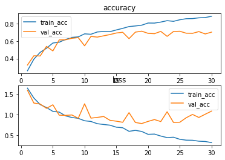

```python
train_acc = history.history['accuracy']
val_acc = history.history['val_accuracy']
train_loss = history.history['loss']
val_loss = history.history['val_loss']


epochs=list(range(1,31))
plt.subplot(2,1,1)
plt.plot(epochs,train_acc,label='train_acc')
plt.plot(epochs,val_acc,label='val_acc')
plt.title('accuracy')
plt.legend()


plt.subplot(2,1,2)
plt.plot(epochs,train_loss,label='train_acc')
plt.plot(epochs,val_loss,label='val_acc')
plt.title('loss')
plt.legend()
```

training loss: 0.3273 training accuracy: 0.8857 valdation loss: 1.0854 validation accuracy: 0.7035

# Prediction aginst user samples

### Prediction of Rose

```
<class 'PIL.JpegImagePlugin.JpegImageFile'>
(238, 212, 3)
<class 'numpy.ndarray'>
(150, 150, 3)
(1, 150, 150, 3)
```

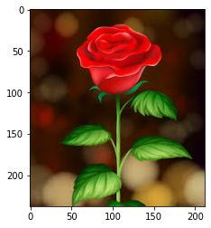

```python
from tensorflow.keras.preprocessing import image
import numpy as np
img = image.load_img('/content/drive/My Drive/flowers/rose.jpg')
print(type(img))
plt.imshow(img)
#print(img.shape)

img = tf.keras.preprocessing.image.img_to_array(img)
print(img.shape)
print(type(img))
img = tf.image.resize(img,(150,150))

#scaling
img = img/255
print(img.shape)
img = np.expand_dims(img,axis=0)
print(img.shape)
```

```python
model.predict(img).round(3)
```

```
array([[0.001, 0.   , 0.987, 0.   , 0.013]], dtype=float32)
```

```python
print(f"The Photo is in the category of {mapping[model.predict_classes(img)[0]]}")
```

```
The Photo is in the category of roses
```

### Prediction of Dandelion

```
<class 'PIL.JpegImagePlugin.JpegImageFile'>
(681, 914, 3)
<class 'numpy.ndarray'>
(150, 150, 3)
(1, 150, 150, 3)
```

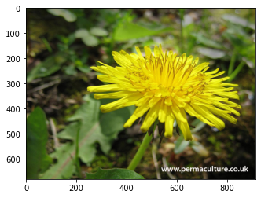

```python
img = image.load_img('/content/drive/My Drive/flowers/DandelionLead.jpg')
print(type(img))
plt.imshow(img)
#print(img.shape)

img = tf.keras.preprocessing.image.img_to_array(img)
print(img.shape)
print(type(img))
img = tf.image.resize(img,(150,150))

#scaling
img = img/255
print(img.shape)
img = np.expand_dims(img,axis=0)
print(img.shape)
```

```python
model.predict(img).round(3)
```

```
array([[0., 1., 0., 0., 0.]], dtype=float32)
```

```python
print(f"The Photo is in the category of {mapping[model.predict_classes(img)[0]]}")
```

```
The Photo is in the category of dandelion
```

### Prediction of Daisy

```
<class 'PIL.JpegImagePlugin.JpegImageFile'>
(2000, 2200, 3)
<class 'numpy.ndarray'>
(150, 150, 3)
(1, 150, 150, 3)
```

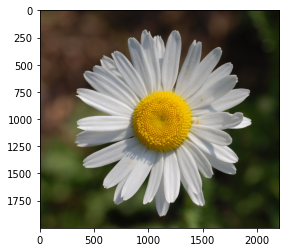

```python
img = image.load_img('/content/drive/My Drive/flowers/daisy.jpg')
print(type(img))
plt.imshow(img)
#print(img.shape)

img = tf.keras.preprocessing.image.img_to_array(img)
print(img.shape)
print(type(img))
img = tf.image.resize(img,(150,150))

#scaling
img = img/255
print(img.shape)
img = np.expand_dims(img,axis=0)
print(img.shape)
```

```python
model.predict(img).round(3)
```

```
array([[1., 0., 0., 0., 0.]], dtype=float32)
```

```python
print(f"The Photo is in the category of {mapping[model.predict_classes(img)[0]]}")
```

```
The Photo is in the category of daisy
```

### Prediction of Tulip

```
<class 'PIL.JpegImagePlugin.JpegImageFile'>
(450, 450, 3)
<class 'numpy.ndarray'>
(150, 150, 3)
(1, 150, 150, 3)
```

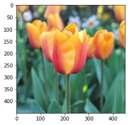

```python
img = image.load_img('/content/drive/My Drive/flowers/tulip.jpg')
print(type(img))
plt.imshow(img)
#print(img.shape)

img = tf.keras.preprocessing.image.img_to_array(img)
print(img.shape)
print(type(img))
img = tf.image.resize(img,(150,150))

#scaling
img = img/255
print(img.shape)
img = np.expand_dims(img,axis=0)
print(img.shape)
```

```python
model.predict(img).round(3)
```

```
array([[0., 0., 0., 0., 1.]], dtype=float32)
```

```python
print(f"The Photo is in the category of {mapping[model.predict_classes(img)[0]]}")
```

```
The Photo is in the category of tulips
```

### Prediction of Sunflower

```
<class 'PIL.JpegImagePlugin.JpegImageFile'>
(646, 862, 3)
<class 'numpy.ndarray'>
(150, 150, 3)
(1, 150, 150, 3)
```

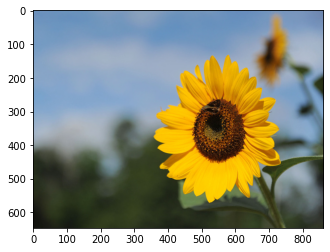

```python
img = image.load_img('/content/drive/My Drive/flowers/sunflower.jpg')
print(type(img))
plt.imshow(img)
#print(img.shape)

img = tf.keras.preprocessing.image.img_to_array(img)
print(img.shape)
print(type(img))
img = tf.image.resize(img,(150,150))

#scaling
img = img/255
print(img.shape)
img = np.expand_dims(img,axis=0)
print(img.shape)
```

```python
model.predict(img).round(3)
```

```
array([[0., 0., 0., 1., 0.]], dtype=float32)
```

```python
print(f"The Photo is in the category of {mapping[model.predict_classes(img)[0]]}")
```

```
The Photo is in the category of sunflowers
```

### Validtaion accurcy of model 1 is : 0.6116 and validation accuracy of model 2 is : 0.7035 .Hence the accuracy of model 2 is better than model 1, model 2 is better than model 1